# Activity: Graphical Exploration

eric weah

Due Date:2/9/2020

## Front Matter

Install supporting R packages with necessary functions and data sets. You will need to add `library(DataComputing)` to the code chunk. Note the line `rm(list = ls())` at the beginning of the code chunk, this will effectively reset your R environment which can help avoid bugs when an analysis gets more complicated.

```r
rm(list = ls())      # cleans up your R environment
# load packages
library(mosaic)
library(tidyverse)   # loads a group of useful packages including `ggplot2`
```

### Explore the `diamonds` data

*Task: Use R to produce one informative graphic of the `diamonds` data. The graphic should represent AT LEAST 3 variables. Write a few sentences to describe what we can learn from the graphic your have provided. (Note: do NOT write your narrative inside the code chunk.)* #The diamonds data has info on different carat dimonds. The data also shows how the dimaond was cut, the clarit, depth and pricing. #The second ggplot shows the 3 varibales of cut, carat, and color. This can show that the bigger the carat the harder is it to get a better cut and diamond.

```r
# read `diamonds` data into R; it has been provided by the `ggplot2` package
data("diamonds", package = "ggplot2")
# add your code below for your one key data visualization
ggplot2::diamonds
```

| carat | cut | color | clarity | depth | table | price | x | y | z |
| --- | --- | --- | --- | --- | --- | --- | --- | --- | --- |
| 0.23 | Ideal | E | SI2 | 61.5 | 55.0 | 326 | 3.95 | 3.98 | 2.43 |
| 0.21 | Premium | E | SI1 | 59.8 | 61.0 | 326 | 3.89 | 3.84 | 2.31 |
| 0.23 | Good | E | VS1 | 56.9 | 65.0 | 327 | 4.05 | 4.07 | 2.31 |
| 0.29 | Premium | I | VS2 | 62.4 | 58.0 | 334 | 4.20 | 4.23 | 2.63 |
| 0.31 | Good | J | SI2 | 63.3 | 58.0 | 335 | 4.34 | 4.35 | 2.75 |
| 0.24 | Very Good | J | VVS2 | 62.8 | 57.0 | 336 | 3.94 | 3.96 | 2.48 |
| 0.24 | Very Good | I | VVS1 | 62.3 | 57.0 | 336 | 3.95 | 3.98 | 2.47 |
| 0.26 | Very Good | H | SI1 | 61.9 | 55.0 | 337 | 4.07 | 4.11 | 2.53 |
| 0.22 | Fair | E | VS2 | 65.1 | 61.0 | 337 | 3.87 | 3.78 | 2.49 |
| 0.23 | Very Good | H | VS1 | 59.4 | 61.0 | 338 | 4.00 | 4.05 | 2.39 |

[output cut: 990 more lines]

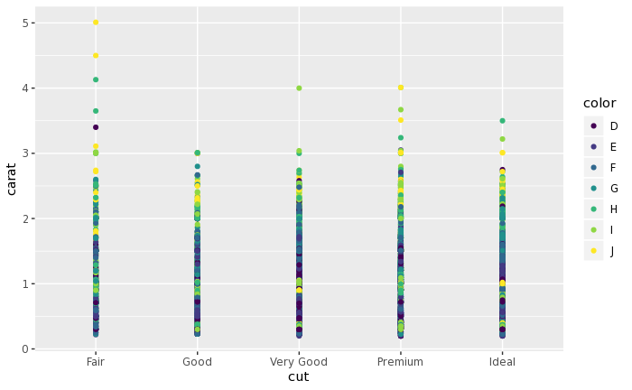

```r
ggplot() + geom_point(data = diamonds, aes(x = cut, y = carat, color = color))
```

### Explore the cereal data

*Task: Use R to produce one informative graphic of the `cereal.csv` data. The graphic should represent AT LEAST 3 variables. Write a few sentences to describe what we can learn from the graphic your have provided. (Note: do NOT write your narrative inside the code chunk.)* #The dataset contains the nutritional value of cerals #The graph produced shows a correlation between and rating. the lower the sugar the higher rating, the higher the sugar the lower the rating.

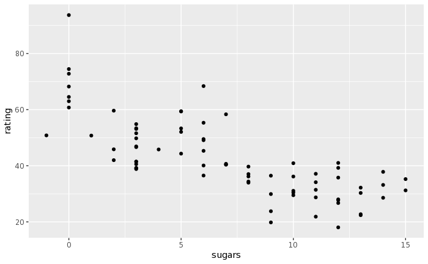

```r
# read CSV data set into R
CerealData <- read_csv(file = "cereal.csv")
# add your code below for your one key data visualization
ggplot(CerealData, aes(sugars, rating)) +
 geom_point()
```

```r
NA
```

### Extension: programming style

The helper functions are great, but they produce ugly code. Clean up the `ggplot2` code that reproduces the required plots so that it aligns with the R Programming Style Guide Appendix in the *DataComputing* eBook https://dtkaplan.github.io/DataComputingEbook/.